# Individual1ZL.Rmd

Zack Larson

# Loading Data

```r
library(tidyverse)
```

```r
library(ggplot2)
library(dplyr)
accident <- read.csv("https://raw.githubusercontent.com/xdaiISU/ds202materials/master/hwlabs/fars2017/accident.csv", stringsAsFactors = FALSE)
person <- read.csv("https://raw.githubusercontent.com/xdaiISU/ds202materials/master/hwlabs/fars2017/person.csv", stringsAsFactors = FALSE)
```

## 1.

According to our findings and the graph shown, there are some days of the week that accidents are more common than others. The graph shows that the weekend is the most likely time to have an accident than during the middle of the week. The graph shows days 1 and 7 as the highest rate of accidents, this represents Sunday and Saturday respectively. This makes sense since people are more likely to drink and drive then and also more free driving compared to the typical weekday where most people drive just to commute to work or get groceries. While on weekends, people are more likely to go and do something more exciting where they don’t pay attention to their driving as much. This is extended even further when noticing that Fridays(day 6) are the 3rd most accident common day of the week therefore concluding that the weekend is the more likely time of the week to get into an accident.

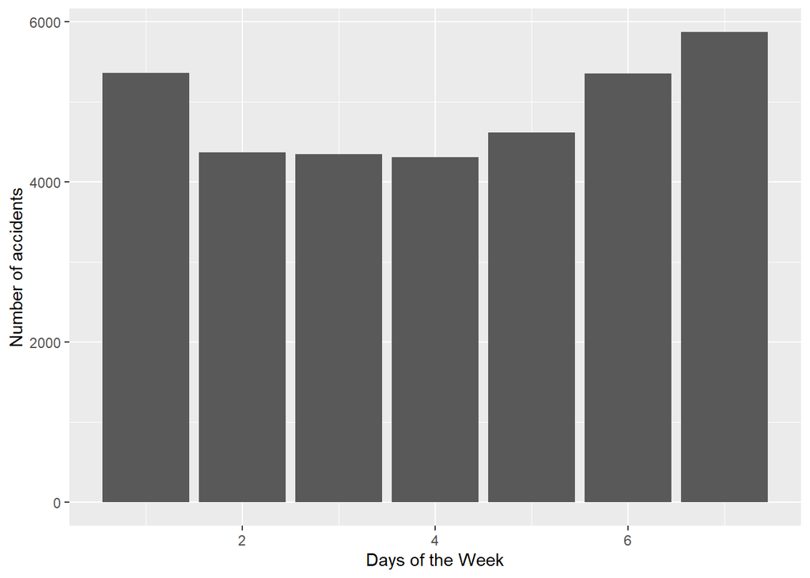

```r
dayOfWeekStats <- accident %>%
    group_by(DAY_WEEK) %>%
    summarise(count = n())

ggplot(dayOfWeekStats, aes(x = DAY_WEEK, y = count)) + geom_col() + xlab("Days of the Week") + ylab("Number of accidents")
```

## 2.

```r
fatalAccidentVictims <- person %>% filter(INJ_SEV == 4)#4 is the code for a fatal injury in the manual provided
```

## 3.

```r
fatalAccidentVictims <- fatalAccidentVictims[!is.na(fatalAccidentVictims$MAKE), ]
StateMakeDF <- fatalAccidentVictims %>% count(STATE, MAKE) %>% group_by(STATE) %>%
  slice(which.max(n))

StateMakeDF
```

```
## # A tibble: 51 x 3
## # Groups:   STATE [51]
##    STATE  MAKE     n
##    <int> <int> <int>
##  1     1    12   138
##  2     2    12     9
##  3     4    20    88
##  4     5    20    88
##  5     6    49   351
##  6     8    12    63
##  7     9    37    28
##  8    10    37    12
##  9    11    37     5
## 10    12    12   237
## # ... with 41 more rows
```

## 4.

```r
library(maps)
states <- map_data('state')
head(states)
```

```
##        long      lat group order  region subregion
## 1 -87.46201 30.38968     1     1 alabama      <NA>
## 2 -87.48493 30.37249     1     2 alabama      <NA>
## 3 -87.52503 30.37249     1     3 alabama      <NA>
## 4 -87.53076 30.33239     1     4 alabama      <NA>
## 5 -87.57087 30.32665     1     5 alabama      <NA>
## 6 -87.58806 30.32665     1     6 alabama      <NA>
```

```r
mapMake <-
  StateMakeDF %>%
  inner_join(states, by = c("STATE" = "group"))
mapMake <- mapMake %>% group_by(STATE) %>% summarise(lat = mean(c(max(lat), min(lat))),long = mean(c(max(long), min(long))),make = max(MAKE))
mapMake
```

```
## # A tibble: 51 x 4
##    STATE   lat   long  make
##  * <dbl> <dbl>  <dbl> <int>
##  1     1  32.6  -86.7    12
##  2     2  34.2 -112.     12
##  3     4  37.3 -119.     20
##  4     5  39.0 -106.     20
##  5     6  41.5  -72.8    49
##  6     8  38.9  -77.0    12
##  7     9  28.1  -83.8    37
##  8    10  32.7  -83.2    37
##  9    11  45.5 -114.     37
## 10    12  39.8  -89.5    12
## # ... with 41 more rows
```

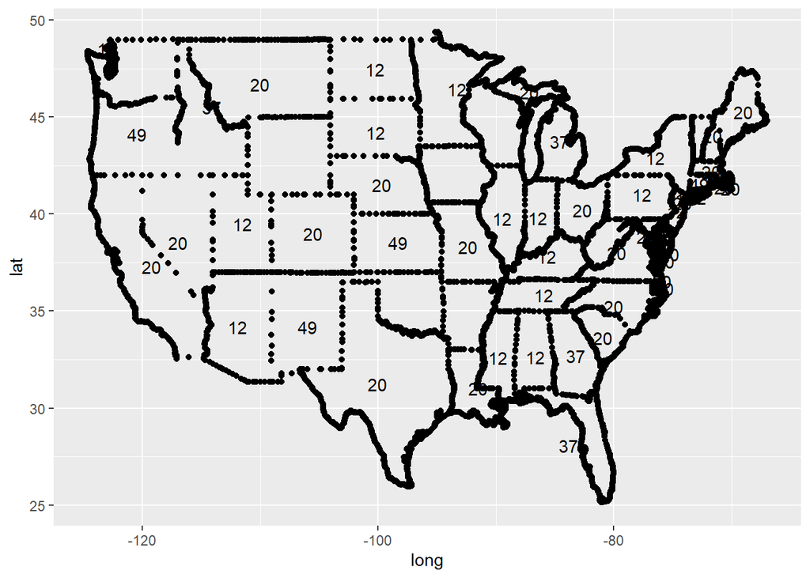

```r
states %>% ggplot(states,mapping=aes(x=long, y=lat)) + geom_point() + geom_text(aes(label = make), data = mapMake)
```

## 5.

```r
peopleAndAccidents <- accident %>%
  full_join(person, by = "ST_CASE")
```

## 6.

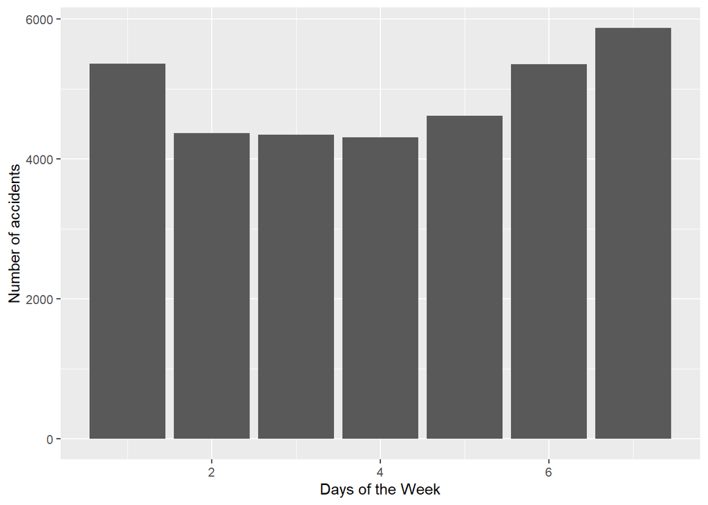

```r
dayOfWeekStats <- accident %>%
    group_by(DAY_WEEK) %>%
    summarise(count = n())

ggplot(dayOfWeekStats, aes(x = DAY_WEEK, y = count)) + geom_col() + xlab("Days of the Week") + ylab("Number of accidents")
```

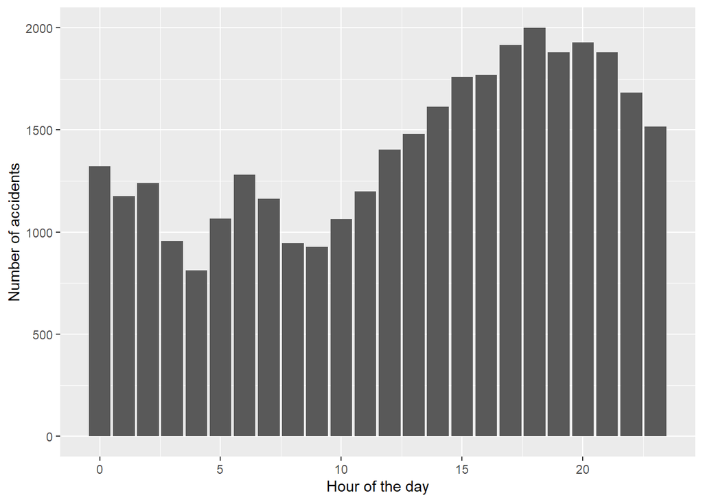

```r
HourStats <- accident %>% filter(HOUR<25) %>%
    group_by(HOUR) %>%
    summarise(count = n())

ggplot(HourStats, aes(x = HOUR, y = count)) + geom_col() + xlab("Hour of the day") + ylab("Number of accidents")
```

```r
SexStats <- accident %>% full_join(person, by="ST_CASE") %>%
    group_by(person$SEX) %>%
    summarise(count = n()) %>% ggplot(aes(x = person$SEX, y = count)) + geom_col() + xlab("Gender") + ylab("Number of accidents")
```